# Single-Nucleus RNA-seq Analysis of Mouse Brain

July 29, 2025

Here, mouse single-nucleus RNA Seq data from [Zhou et al., 2020](https://pubmed.ncbi.nlm.nih.gov/31932797/) paper are analysed, comparing wild type (WT) and disease (5XFAD) samples. The paper studies Alzheimer’s disease (AD), which occurs when amyloid beta (Aβ) peptides produced by neurons form aggregates in the brain. As is known, this is followed by intraneuronal tau hyperphosphorylation and aggregation resulting in neuronal and synaptic dysfunction and cell death. Reactive astrocytosis and microgliosis are believed to be secondary cellular responses that occur in diseased brain regions.

# 1 Creating Seurat object for mouse brain datasets

## 1.1 Pre-processing GSM4173504: WT

[GSM4173504_WT_1](https://www.ncbi.nlm.nih.gov/geo/query/acc.cgi?acc=GSM4173504) : Sample isolated single nuclei from brain of wild type mice at the age of 7 months.

```r
# WT
counts_WT <- ReadMtx(mtx =  "C:/Users/HP/OneDrive/Desktop/SnRNASeq_MB/GSM4173504_WT_1/matrix.mtx.gz", cells = "C:/Users/HP/OneDrive/Desktop/SnRNASeq_MB/GSM4173504_WT_1/barcodes.tsv.gz", features = "C:/Users/HP/OneDrive/Desktop/SnRNASeq_MB/GSM4173504_WT_1/features.tsv.gz")
data_WT <- CreateSeuratObject(counts = counts_WT, project = "WT_1", min.cells = 5, min.features = 5)
data_WT[["percent.mt"]] <- PercentageFeatureSet(data_WT, pattern = "^mt-")

range(data_WT$nCount_RNA)
```

```
## [1]   501 35090
```

UMI counts for cells in the WT dataset range from 501 - 35090. It is then filtered for UMI counts in the range [300,9000].

```r
range(data_WT$nFeature_RNA)
```

```
## [1]  300 8101
```

The number of unique genes in a cell in the WT dataset range from 300 - 8101. The cells are then filtered for number of unique genes in each cell in the range [300, 5600] as well as low percentage of mitochondrial genes(<5% ).

```r
data_WT <- subset(data_WT, nCount_RNA >= 300 & nCount_RNA < 9001 &
                    nFeature_RNA >= 300 & nFeature_RNA < 5601 &
                    percent.mt < 5)
data_WT$sample_name <- "WT"
head(data_WT)
```

|  | orig.ident | nCount_RNA | nFeature_RNA | percent.mt | sample_name |
| --- | --- | --- | --- | --- | --- |
| AAACCTGAGAATGTGT-1 | WT_1 | 6606 | 3423 | 0.13623978 | WT |
| AAACCTGAGATATGGT-1 | WT_1 | 3552 | 2212 | 0.05630631 | WT |
| AAACCTGAGATCCCAT-1 | WT_1 | 601 | 452 | 0.16638935 | WT |
| AAACCTGAGATGTGGC-1 | WT_1 | 3360 | 2243 | 0.02976190 | WT |
| AAACCTGAGTAGATGT-1 | WT_1 | 1063 | 815 | 0.09407338 | WT |
| AAACCTGAGTCTCAAC-1 | WT_1 | 5626 | 3018 | 0.08887309 | WT |
| AAACCTGAGTGTCTCA-1 | WT_1 | 4479 | 2740 | 0.13395847 | WT |
| AAACCTGCAACTTGAC-1 | WT_1 | 6176 | 3228 | 0.74481865 | WT |
| AAACCTGCAAGTACCT-1 | WT_1 | 5663 | 3188 | 0.00000000 | WT |
| AAACCTGCACGAAGCA-1 | WT_1 | 2021 | 1395 | 0.04948046 | WT |

|  | orig.ident <fct> | nCount_RNA <dbl> | nFeature_RNA <int> | percent.mt <dbl> | sample_name <chr> |
| --- | --- | --- | --- | --- | --- |
| AAACCTGAGAATGTGT-1 | WT_1 | 6606 | 3423 | 0.13623978 | WT |
| AAACCTGAGATATGGT-1 | WT_1 | 3552 | 2212 | 0.05630631 | WT |
| AAACCTGAGATCCCAT-1 | WT_1 | 601 | 452 | 0.16638935 | WT |
| AAACCTGAGATGTGGC-1 | WT_1 | 3360 | 2243 | 0.02976190 | WT |
| AAACCTGAGTAGATGT-1 | WT_1 | 1063 | 815 | 0.09407338 | WT |
| AAACCTGAGTCTCAAC-1 | WT_1 | 5626 | 3018 | 0.08887309 | WT |
| AAACCTGAGTGTCTCA-1 | WT_1 | 4479 | 2740 | 0.13395847 | WT |
| AAACCTGCAACTTGAC-1 | WT_1 | 6176 | 3228 | 0.74481865 | WT |
| AAACCTGCAAGTACCT-1 | WT_1 | 5663 | 3188 | 0.00000000 | WT |
| AAACCTGCACGAAGCA-1 | WT_1 | 2021 | 1395 | 0.04948046 | WT |

1-10 of 10 rows

## 1.2 Pre-processing GSM4173511: 5XFAD

[GSM4173511_WT_5XFAD_2](https://www.ncbi.nlm.nih.gov/geo/query/acc.cgi?acc=GSM4173511) : Sample isolated single nuclei from brain of 5XFAD mice at the age of 7 months. The 5XFAD mice are a widely used transgenic mouse model for studying Alzheimer’s disease (AD), focusing on amyloid-beta (Aβ) pathology.

```r
# 5XFAD
counts_AD <- ReadMtx(
  mtx = "C:/Users/HP/OneDrive/Desktop/SnRNASeq_MB/GSM4173511_AD_2/GSM4173511_WT_5XFAD_2_matrix.mtx.gz",
  cells = "C:/Users/HP/OneDrive/Desktop/SnRNASeq_MB/GSM4173511_AD_2/GSM4173511_WT_5XFAD_2_barcodes.tsv.gz",
  features = "C:/Users/HP/OneDrive/Desktop/SnRNASeq_MB/GSM4173511_AD_2/GSM4173511_WT_5XFAD_2_features.tsv.gz"
)
data_5XFAD <- CreateSeuratObject(counts = counts_AD, project = "AD_2", min.cells = 5, min.features = 100)

data_5XFAD[["percent.mt"]] <- PercentageFeatureSet(data_5XFAD, pattern = "^mt-")
range(data_5XFAD$nCount_RNA)
```

```
## [1]   499 24598
```

```r
range(data_5XFAD$nFeature_RNA)
```

```
## [1]  244 6647
```

```r
data_5XFAD <- subset(data_5XFAD, nCount_RNA >= 300 & nCount_RNA < 9001 &
                    nFeature_RNA >= 300 & nFeature_RNA < 5601 &
                    percent.mt < 5)
data_5XFAD$sample_name <- "AD"
head(data_5XFAD)
```

|  | orig.ident | nCount_RNA | nFeature_RNA | percent.mt | sample_name |
| --- | --- | --- | --- | --- | --- |
| AAACCTGAGATCTGAA-1 | AD_2 | 1224 | 844 | 0.08169935 | AD |
| AAACCTGAGCGACGTA-1 | AD_2 | 3157 | 1934 | 0.03167564 | AD |
| AAACCTGAGCGATTCT-1 | AD_2 | 1392 | 967 | 0.07183908 | AD |
| AAACCTGAGCTAGTCT-1 | AD_2 | 1298 | 1023 | 0.00000000 | AD |
| AAACCTGAGTACCGGA-1 | AD_2 | 518 | 420 | 0.38610039 | AD |
| AAACCTGAGTCATGCT-1 | AD_2 | 505 | 421 | 0.39603960 | AD |
| AAACCTGAGTTATCGC-1 | AD_2 | 986 | 748 | 1.92697769 | AD |
| AAACCTGCAAACCTAC-1 | AD_2 | 5820 | 3015 | 0.00000000 | AD |
| AAACCTGCAAGGTTCT-1 | AD_2 | 5117 | 2818 | 0.25405511 | AD |
| AAACCTGCAGAAGCAC-1 | AD_2 | 2751 | 1874 | 0.00000000 | AD |

|  | orig.ident <fct> | nCount_RNA <dbl> | nFeature_RNA <int> | percent.mt <dbl> | sample_name <chr> |
| --- | --- | --- | --- | --- | --- |
| AAACCTGAGATCTGAA-1 | AD_2 | 1224 | 844 | 0.08169935 | AD |
| AAACCTGAGCGACGTA-1 | AD_2 | 3157 | 1934 | 0.03167564 | AD |
| AAACCTGAGCGATTCT-1 | AD_2 | 1392 | 967 | 0.07183908 | AD |
| AAACCTGAGCTAGTCT-1 | AD_2 | 1298 | 1023 | 0.00000000 | AD |
| AAACCTGAGTACCGGA-1 | AD_2 | 518 | 420 | 0.38610039 | AD |
| AAACCTGAGTCATGCT-1 | AD_2 | 505 | 421 | 0.39603960 | AD |
| AAACCTGAGTTATCGC-1 | AD_2 | 986 | 748 | 1.92697769 | AD |
| AAACCTGCAAACCTAC-1 | AD_2 | 5820 | 3015 | 0.00000000 | AD |
| AAACCTGCAAGGTTCT-1 | AD_2 | 5117 | 2818 | 0.25405511 | AD |
| AAACCTGCAGAAGCAC-1 | AD_2 | 2751 | 1874 | 0.00000000 | AD |

1-10 of 10 rows

## 1.3 Summary of the two datasets

```r
n_cells_WT <- ncol(data_WT[["RNA"]]@layers$counts)
n_umis_WT <- sum(data_WT[["RNA"]]@layers$counts)
n_genes_WT <- nrow(data_WT[["RNA"]]@layers$counts)


n_cells_AD <- ncol(data_5XFAD[["RNA"]]@layers$counts)
n_umis_AD <- sum(data_5XFAD[["RNA"]]@layers$counts)
n_genes_AD <- nrow(data_5XFAD[["RNA"]]@layers$counts)

summary_table <- data.frame(
  Sample = c("WT", "5XFAD"),
  Genes = c(n_genes_WT, n_genes_AD),
  UMIs = c(n_umis_WT, n_umis_AD),
  Cells = c(n_cells_WT, n_cells_AD)
)

summary_table
```

| Sample | Genes | UMIs | Cells |
| --- | --- | --- | --- |
| WT | 18863 | 33827107 | 9651 |
| 5XFAD | 17735 | 15032624 | 4559 |

| Sample <chr> | Genes <int> | UMIs <dbl> | Cells <int> |  |
| --- | --- | --- | --- | --- |
| WT | 18863 | 33827107 | 9651 |  |
| 5XFAD | 17735 | 15032624 | 4559 |  |

2 rows

After filtering for quality of reads, WT dataset contains 9651 cells whereas AD dataset contains 4559

## 1.4 Creating a combined seurat object using WT and 5XFAD datasets

```r
objects <- merge(data_WT, y = data_5XFAD, add.cell.ids = c("WT", "AD"))
saveRDS(objects, file = "C:/Users/HP/OneDrive/Desktop/SnRNASeq_MB/seurat_obj.rds")

dim(objects)
```

```
## [1] 19027 14210
```

```r
head(objects)
```

|  | orig.ident | nCount_RNA | nFeature_RNA | percent.mt | sample_name |
| --- | --- | --- | --- | --- | --- |
| WT_AAACCTGAGAATGTGT-1 | WT_1 | 6606 | 3423 | 0.13623978 | WT |
| WT_AAACCTGAGATATGGT-1 | WT_1 | 3552 | 2212 | 0.05630631 | WT |
| WT_AAACCTGAGATCCCAT-1 | WT_1 | 601 | 452 | 0.16638935 | WT |
| WT_AAACCTGAGATGTGGC-1 | WT_1 | 3360 | 2243 | 0.02976190 | WT |
| WT_AAACCTGAGTAGATGT-1 | WT_1 | 1063 | 815 | 0.09407338 | WT |
| WT_AAACCTGAGTCTCAAC-1 | WT_1 | 5626 | 3018 | 0.08887309 | WT |
| WT_AAACCTGAGTGTCTCA-1 | WT_1 | 4479 | 2740 | 0.13395847 | WT |
| WT_AAACCTGCAACTTGAC-1 | WT_1 | 6176 | 3228 | 0.74481865 | WT |
| WT_AAACCTGCAAGTACCT-1 | WT_1 | 5663 | 3188 | 0.00000000 | WT |
| WT_AAACCTGCACGAAGCA-1 | WT_1 | 2021 | 1395 | 0.04948046 | WT |

|  | orig.ident <chr> | nCount_RNA <dbl> | nFeature_RNA <int> | percent.mt <dbl> | sample_name <chr> |
| --- | --- | --- | --- | --- | --- |
| WT_AAACCTGAGAATGTGT-1 | WT_1 | 6606 | 3423 | 0.13623978 | WT |
| WT_AAACCTGAGATATGGT-1 | WT_1 | 3552 | 2212 | 0.05630631 | WT |
| WT_AAACCTGAGATCCCAT-1 | WT_1 | 601 | 452 | 0.16638935 | WT |
| WT_AAACCTGAGATGTGGC-1 | WT_1 | 3360 | 2243 | 0.02976190 | WT |
| WT_AAACCTGAGTAGATGT-1 | WT_1 | 1063 | 815 | 0.09407338 | WT |
| WT_AAACCTGAGTCTCAAC-1 | WT_1 | 5626 | 3018 | 0.08887309 | WT |
| WT_AAACCTGAGTGTCTCA-1 | WT_1 | 4479 | 2740 | 0.13395847 | WT |
| WT_AAACCTGCAACTTGAC-1 | WT_1 | 6176 | 3228 | 0.74481865 | WT |
| WT_AAACCTGCAAGTACCT-1 | WT_1 | 5663 | 3188 | 0.00000000 | WT |
| WT_AAACCTGCACGAAGCA-1 | WT_1 | 2021 | 1395 | 0.04948046 | WT |

1-10 of 10 rows

```r
counts_wt <- GetAssayData(object = objects, assay = "RNA", layer = "counts.WT_1")
counts_ad <- GetAssayData(object = objects, assay = "RNA", layer = "counts.AD_2")

non_zero_entries_in_WT <- round(sum(counts_wt>0)/(dim(counts_wt)[1]*dim(counts_wt)[2]), 2)*100

non_zero_entries_in_WT
```

```
## [1] 11
```

```r
non_zero_entries_in_AD <- round(sum(counts_ad>0)/(dim(counts_ad)[1]*dim(counts_ad)[2]), 2)*100
non_zero_entries_in_AD
```

```
## [1] 11
```

Approximately 11% of values in WT and 5XFAD count matrices are non-zero, after filtering for quality of samples.

## 1.5 Relation between Gene Mean Expression and Variance

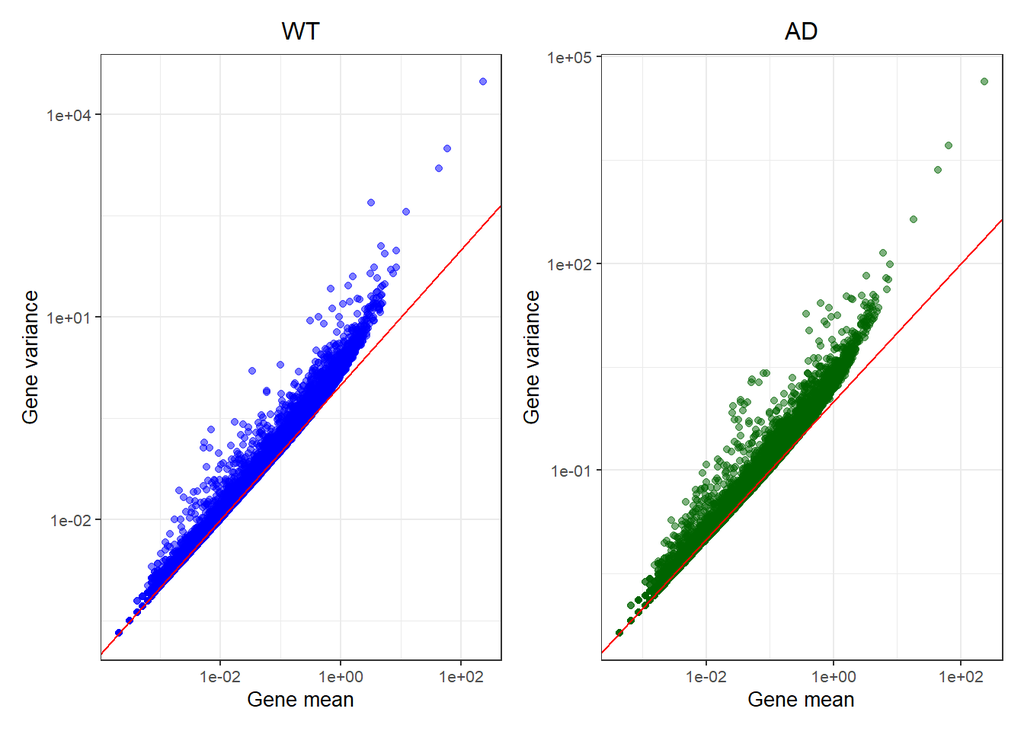

```r
gene_mean_wt <- rowMeans(counts_wt)
gene_var_wt <- apply(counts_wt, 1, var)

gene_mean_ad <- rowMeans(counts_ad)
gene_var_ad <- apply(counts_ad, 1, var)

# WT plot
p_wt <- ggplot(data.frame(gene_mean = gene_mean_wt, gene_variance = gene_var_wt),
               aes(x = gene_mean, y = gene_variance)) +
  geom_point(color = "blue", alpha = 0.5) +
  geom_abline(color = "red") +
  scale_x_log10() +
  scale_y_log10() +
  ggtitle("WT") +
  xlab("Gene mean") +
  ylab("Gene variance") +
  theme_bw(base_size = 10)+base_theme

# AD plot
p_ad <- ggplot(data.frame(gene_mean = gene_mean_ad, gene_variance = gene_var_ad),
               aes(x = gene_mean, y = gene_variance)) +
  geom_point(color = "darkgreen", alpha = 0.5) +
  geom_abline(color = "red") +
  scale_x_log10() +
  scale_y_log10() +
  ggtitle("AD") +
  xlab("Gene mean") +
  ylab("Gene variance") +
  theme_bw(base_size = 10) +base_theme

p_wt + p_ad
```

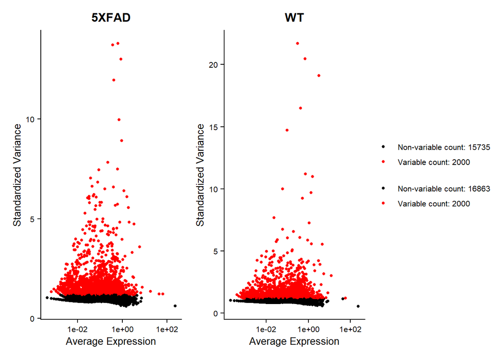

```r
AD<- FindVariableFeatures(object = data_5XFAD, selection.method = "vst")
p2_ad <-VariableFeaturePlot(AD) +
  ggtitle("5XFAD") +base_theme

WT<- FindVariableFeatures(object = data_WT, selection.method = "vst")
p2_wt <-VariableFeaturePlot(WT) + ggtitle("WT")+base_theme

p2_ad + p2_wt + plot_layout(ncol = 2, guides = "collect")
```

## 1.6 Data Normalization

To achieve minimal dependence of gene expression values on sequencing depth and technical noise, the data is normalised using SCTransform.

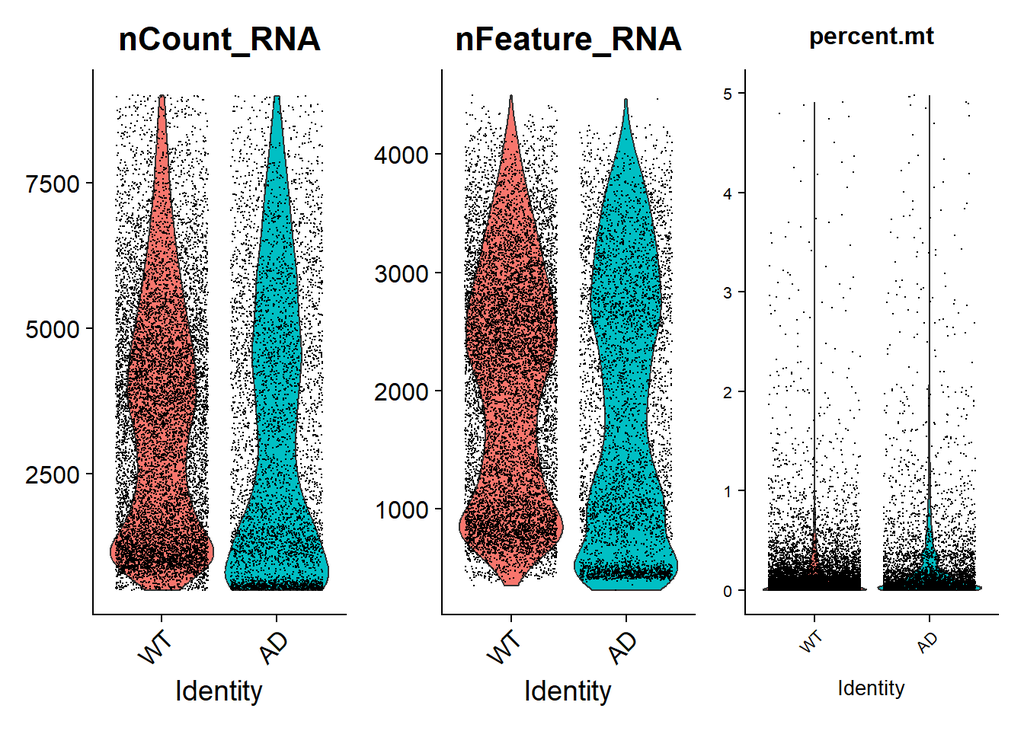

```r
objects <- SCTransform(objects, vst.flavor = "v2", verbose = TRUE)

var.features <- VariableFeatures(objects)

counts <- GetAssayData(object = objects, assay = "SCT", slot = "counts")

sct.data <- GetAssayData(object = objects, assay = "SCT", slot = "data")

corr.sct <- apply(
  X = sct.data[intersect(var.features, rownames(sct.data)), ],
  MARGIN = 1,
  FUN = function(x) cor(x = x, y = colSums(counts))
)
counts_wt <- GetAssayData(object = objects, assay = "RNA", slot = "counts.WT_1")
counts_ad <- GetAssayData(object = objects, assay = "RNA", slot = "counts.AD_2")

cells_wt <- WhichCells(objects, expression = sample_name == "WT")
cells_ad <- WhichCells(objects, expression = sample_name == "AD")

var.features.wt <- VariableFeatures(FindVariableFeatures(subset(objects, cells = cells_wt)))
var.features.ad <- VariableFeatures(FindVariableFeatures(subset(objects, cells = cells_ad)))


objects <- NormalizeData(object = objects, assay = "RNA", scale.factor = 10000)

lognormalized.data_WT <- GetAssayData(object = objects, assay = "RNA", slot = "data.WT_1")
lognormalized.data_5XFAD <- GetAssayData(object = objects, assay = "RNA", slot = "data.AD_2")

Idents(objects)<-objects$sample_name
VlnPlot(objects, features = c("nCount_RNA", "nFeature_RNA", "percent.mt")) +base_theme
```

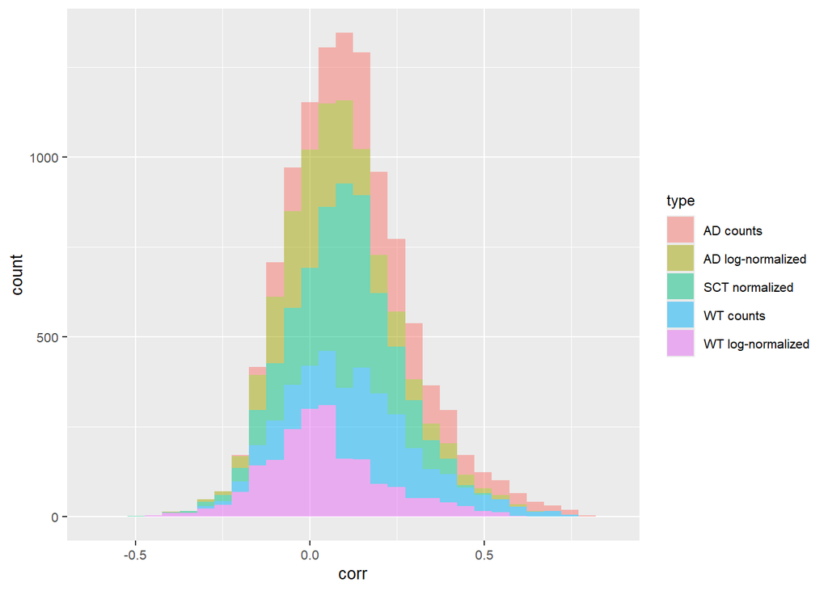

```r
corr.counts.ad <- apply(X = counts_ad[var.features.ad, ], MARGIN = 1,
                        FUN = function(x) cor(x, colSums(counts_ad)))

corr.lognorm.ad <- apply(X = lognormalized.data_5XFAD[var.features.ad, ], MARGIN = 1,
                         FUN = function(x) cor(x, colSums(counts_ad)))
corr.counts.wt <- apply(X = counts_wt[var.features.wt, ], MARGIN = 1,
                        FUN = function(x) cor(x, colSums(counts_wt)))

corr.lognorm.wt <- apply(X = lognormalized.data_WT[var.features.wt, ], MARGIN = 1,
                         FUN = function(x) cor(x, colSums(counts_wt)))

df <- data.frame(
  corr = c(
    corr.counts.wt,
    corr.counts.ad,
    corr.lognorm.wt,
    corr.lognorm.ad,
    corr.sct
  ),
  type = c(
    rep("WT counts", length(corr.counts.wt)),
    rep("AD counts", length(corr.counts.ad)),
    rep("WT log-normalized", length(corr.lognorm.wt)),
    rep("AD log-normalized", length(corr.lognorm.ad)),
    rep("SCT normalized", length(corr.sct))
  )
)


ggplot(df, aes(corr, fill = type)) +
  geom_histogram(alpha = 0.5) + base_theme
```

The graph shows distribution gene expression counts in each dataset and their correlation with sequencing depth of the cells in that dataset.

## 1.7 Dimensionality Reduction

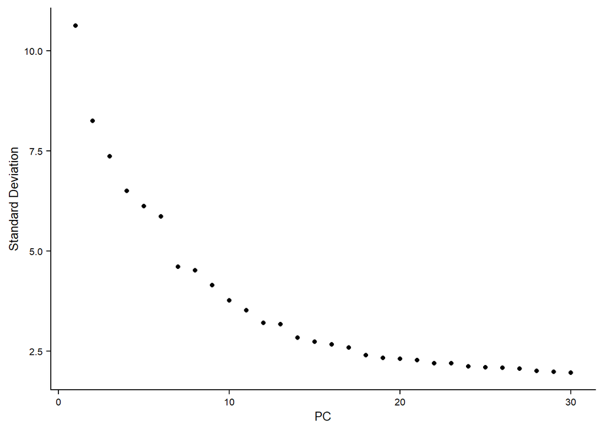

```r
all_genes <- unique(c(VariableFeatures(objects), "Clps", "Pla2g1b", "Pgc", "Cst7", "Vmn1r209", "Gal"))
objects <- ScaleData(objects, features = all_genes)
objects <- RunPCA(objects, features = all_genes, npcs = 50, verbose = TRUE)
ElbowPlot(objects, ndims = 30)+base_theme
```

The first 5 PCs capture about ~45% of standard deviation in dataset. Around PC30, the plot hits a plateau and the remaining components add only very small amount of additional variability. So, PC1 - PC30 are used for further analysis.

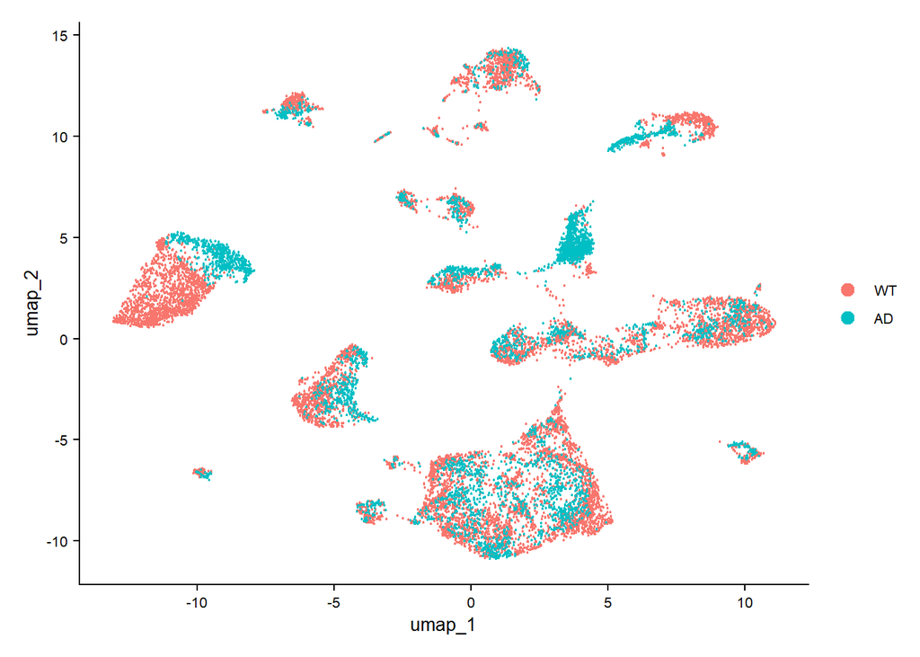

```r
objects <-RunUMAP(object = objects, reduction = 'pca', dims = 1:30)
DimPlot(objects) +base_theme
```

The above plot shows the arrangement of cells in WT and 5XFAD datasets into various clusters in 2D space. Some clusters are overlapping in WT and 5XFAD whereas others vary in both density of cells in a given cluster as well as their arrangement.

```r
objects <- FindNeighbors(objects, reduction = 'pca', dims = 1:30)
objects <- FindClusters(objects, resolution = 0.3)
```

```
## Modularity Optimizer version 1.3.0 by Ludo Waltman and Nees Jan van Eck
##
## Number of nodes: 14210
## Number of edges: 511448
##
## Running Louvain algorithm...
## Maximum modularity in 10 random starts: 0.9588
## Number of communities: 17
## Elapsed time: 1 seconds
```

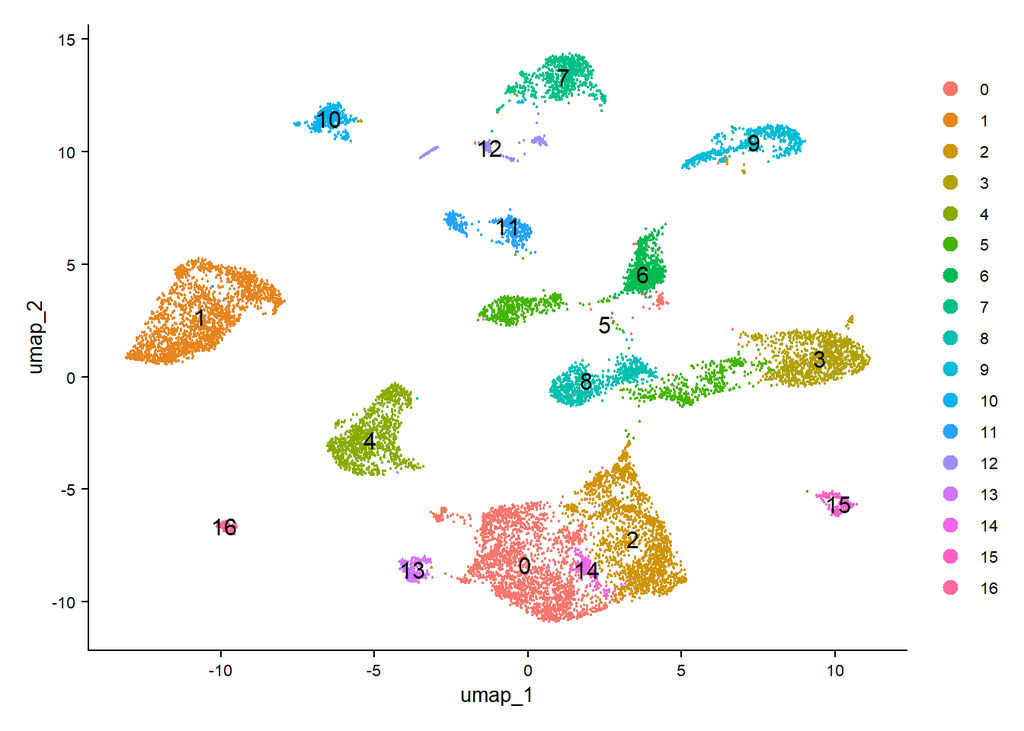

```r
DimPlot(objects, label=TRUE, label.size = 4) + base_theme
```

To find clusters of cells, potentially representing same cell type in brain tissue, the data is clustered. Here, the dataset is reduced to 17 different clusters.

# 2 Differential Expression Analysis in 5XFAD vs WT

## 2.1 Identifying overall upregulated and downregulated genes

Here, genes which are differentially expressed in Alzheimer’s disease model i.e. in the 5XFAD dataset as compared to WT mouse dataset are identified. For this, corrected counts from “SCT” assay are used.

```r
objects <- PrepSCTFindMarkers(objects, verbose = TRUE)
Idents(objects)<- objects$sample_name

all.markers <- FindMarkers(objects, ident.1 = "AD", ident.2 = "WT", verbose = TRUE)
```

Identifying significantly upregulated and downregulated genes using thresholds - |avg_log2FC| > 0.5 and p_adj <0.05

```r
all.markers$gene <- rownames(all.markers)
all.markers$log10_pval <- -log10(all.markers$p_val_adj)
all.markers$significant <- with(all.markers,
                                     ifelse(p_val_adj < 0.05 & abs(avg_log2FC) > 0.5, "Yes", "No")
)

write.csv(all.markers, file = "degs.csv", row.names = FALSE)

top_genes <- all.markers[all.markers$significant == "Yes", ]
top_genes <- top_genes[order(top_genes$avg_log2FC), ]

head(top_genes)
```

|  | p_val | avg_log2FC | pct.1 | pct.2 | p_val_adj | gene | log10_pval | significant |
| --- | --- | --- | --- | --- | --- | --- | --- | --- |
| Plin4 | 2.331793e-07 | -2.503001 | 0.003 | 0.011 | 4.395197e-03 | Plin4 | 2.357022 | Yes |
| Rpe65 | 3.478659e-08 | -2.377471 | 0.002 | 0.011 | 6.556924e-04 | Rpe65 | 3.183300 | Yes |
| Etnppl | 3.813898e-15 | -2.116819 | 0.005 | 0.024 | 7.188816e-11 | Etnppl | 10.143343 | Yes |
| Btg2 | 2.758626e-70 | -1.846017 | 0.055 | 0.160 | 5.199735e-66 | Btg2 | 65.284019 | Yes |
| Fos | 8.718793e-42 | -1.813091 | 0.026 | 0.086 | 1.643405e-37 | Fos | 36.784255 | Yes |
| Xlr3b | 3.963339e-11 | -1.805564 | 0.005 | 0.019 | 7.470499e-07 | Xlr3b | 6.126650 | Yes |

|  | p_val <dbl> | avg_log2FC <dbl> | pct.1 <dbl> | pct.2 <dbl> | p_val_adj <dbl> | gene <chr> | log10_pval <dbl> | significant <chr> |
| --- | --- | --- | --- | --- | --- | --- | --- | --- |
| Plin4 | 2.331793e-07 | -2.503001 | 0.003 | 0.011 | 4.395197e-03 | Plin4 | 2.357022 | Yes |
| Rpe65 | 3.478659e-08 | -2.377471 | 0.002 | 0.011 | 6.556924e-04 | Rpe65 | 3.183300 | Yes |
| Etnppl | 3.813898e-15 | -2.116819 | 0.005 | 0.024 | 7.188816e-11 | Etnppl | 10.143343 | Yes |
| Btg2 | 2.758626e-70 | -1.846017 | 0.055 | 0.160 | 5.199735e-66 | Btg2 | 65.284019 | Yes |
| Fos | 8.718793e-42 | -1.813091 | 0.026 | 0.086 | 1.643405e-37 | Fos | 36.784255 | Yes |
| Xlr3b | 3.963339e-11 | -1.805564 | 0.005 | 0.019 | 7.470499e-07 | Xlr3b | 6.126650 | Yes |

6 rows

```r
de.pos = all.markers %>%
  filter(avg_log2FC>0) %>% filter(p_val_adj<0.05) %>% pull (gene)
length(de.pos)
```

```
## [1] 181
```

```r
de.neg = all.markers %>%
  filter(avg_log2FC<0) %>% filter(p_val_adj<0.05) %>% pull (gene)
length(de.neg)
```

```
## [1] 2067
```

```r
top_upregulated_genes <- all.markers %>%
  filter(p_val_adj < 0.05) %>%
  filter(avg_log2FC >0.5) %>%
  top_n(n = 5, wt = avg_log2FC)

top_downregulated_genes <- all.markers %>%
  filter(avg_log2FC < -0.5, p_val_adj < 0.5) %>%
  arrange(avg_log2FC)%>%
  head(5)

top_upregulated_genes
```

|  | p_val | avg_log2FC | pct.1 | pct.2 | p_val_adj | gene | log10_pval | significant |
| --- | --- | --- | --- | --- | --- | --- | --- | --- |
| Cst7 | 4.983291e-52 | 8.830154 | 0.024 | 0.000 | 9.393006e-48 | Cst7 | 47.02720 | Yes |
| Lilrb4a | 2.577229e-29 | 4.956430 | 0.015 | 0.001 | 4.857818e-25 | Lilrb4a | 24.31356 | Yes |
| Ccl3 | 1.437502e-22 | 7.329889 | 0.010 | 0.000 | 2.709548e-18 | Ccl3 | 17.56710 | Yes |
| Ccl6 | 5.478127e-21 | 3.028190 | 0.016 | 0.002 | 1.032572e-16 | Ccl6 | 15.98608 | Yes |
| Ccl4 | 7.543951e-18 | 4.169424 | 0.010 | 0.001 | 1.421959e-13 | Ccl4 | 12.84711 | Yes |

|  | p_val <dbl> | avg_log2FC <dbl> | pct.1 <dbl> | pct.2 <dbl> | p_val_adj <dbl> | gene <chr> | log10_pval <dbl> | significant <chr> |
| --- | --- | --- | --- | --- | --- | --- | --- | --- |
| Cst7 | 4.983291e-52 | 8.830154 | 0.024 | 0.000 | 9.393006e-48 | Cst7 | 47.02720 | Yes |
| Lilrb4a | 2.577229e-29 | 4.956430 | 0.015 | 0.001 | 4.857818e-25 | Lilrb4a | 24.31356 | Yes |
| Ccl3 | 1.437502e-22 | 7.329889 | 0.010 | 0.000 | 2.709548e-18 | Ccl3 | 17.56710 | Yes |
| Ccl6 | 5.478127e-21 | 3.028190 | 0.016 | 0.002 | 1.032572e-16 | Ccl6 | 15.98608 | Yes |
| Ccl4 | 7.543951e-18 | 4.169424 | 0.010 | 0.001 | 1.421959e-13 | Ccl4 | 12.84711 | Yes |

5 rows

```r
top_downregulated_genes
```

|  | p_val | avg_log2FC | pct.1 | pct.2 | p_val_adj | gene | log10_pval | significant |
| --- | --- | --- | --- | --- | --- | --- | --- | --- |
| Plin4 | 2.331793e-07 | -2.503001 | 0.003 | 0.011 | 4.395197e-03 | Plin4 | 2.3570217 | Yes |
| Rpe65 | 3.478659e-08 | -2.377471 | 0.002 | 0.011 | 6.556924e-04 | Rpe65 | 3.1832998 | Yes |
| Etnppl | 3.813898e-15 | -2.116819 | 0.005 | 0.024 | 7.188816e-11 | Etnppl | 10.1433427 | Yes |
| Plekhf1 | 9.993522e-06 | -1.946236 | 0.003 | 0.010 | 1.883679e-01 | Plekhf1 | 0.7249931 | No |
| Btg2 | 2.758626e-70 | -1.846017 | 0.055 | 0.160 | 5.199735e-66 | Btg2 | 65.2840188 | Yes |

|  | p_val <dbl> | avg_log2FC <dbl> | pct.1 <dbl> | pct.2 <dbl> | p_val_adj <dbl> | gene <chr> | log10_pval <dbl> | significant <chr> |
| --- | --- | --- | --- | --- | --- | --- | --- | --- |
| Plin4 | 2.331793e-07 | -2.503001 | 0.003 | 0.011 | 4.395197e-03 | Plin4 | 2.3570217 | Yes |
| Rpe65 | 3.478659e-08 | -2.377471 | 0.002 | 0.011 | 6.556924e-04 | Rpe65 | 3.1832998 | Yes |
| Etnppl | 3.813898e-15 | -2.116819 | 0.005 | 0.024 | 7.188816e-11 | Etnppl | 10.1433427 | Yes |
| Plekhf1 | 9.993522e-06 | -1.946236 | 0.003 | 0.010 | 1.883679e-01 | Plekhf1 | 0.7249931 | No |
| Btg2 | 2.758626e-70 | -1.846017 | 0.055 | 0.160 | 5.199735e-66 | Btg2 | 65.2840188 | Yes |

5 rows

181 genes were upregulated in 5XFAD as compared to WT, whereas 2067 of them were downregulated. The genes upregulated in 5XFAD include DAM genes like Cst7, Trem2 and Lilrb4a. Homeostatic genes like P2ry12, Trem119, Cx3cr1 and Selplg which are reported to be downregulated in microglial cluster, as reported by [Zhou et al., 2020](https://pubmed.ncbi.nlm.nih.gov/31932797/) were not statistically significant in this analysis, possibly because of not including replicate data of 5XFAD and WT samples.

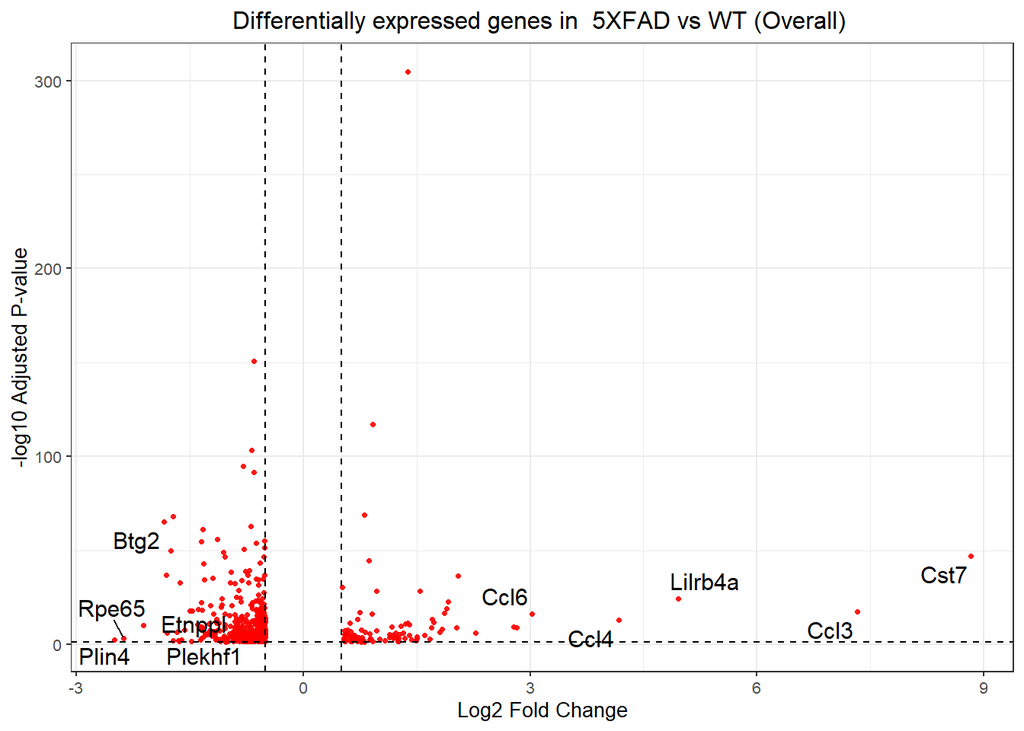

```r
label_genes <- bind_rows(top_upregulated_genes, top_downregulated_genes)


ggplot(top_genes, aes(x = avg_log2FC, y = log10_pval)) +
  geom_point(color = "red", alpha = 0.9, size = 0.95) +
  geom_vline(xintercept = c(-0.5, 0.5), linetype = "dashed") +
  geom_hline(yintercept = -log10(0.05), linetype = "dashed") +
  geom_text_repel(data = label_genes, aes(label = gene), size = 4, max.overlaps = 50) +
  theme_bw(base_size = 10) +
  labs(title = "Differentially expressed genes in  5XFAD vs WT (Overall) ",
       x = "Log2 Fold Change",
       y = "-log10 Adjusted P-value") +
  theme(legend.position = "none") +base_theme
```

## 2.2 Expression of marker genes in different clusters

The expression of known markers for different cell types of brain tissue will help identify cell clusters in UMAP previously obtained. For example, Slc17a7, Grin2a, Snap25 and Syt1 are known to be marker genes for excitatory neurons. Similarly, Gad1, Gad2, Sst and Npy are marker genes for interneurons, whereas Slc1a2, Gja1 and Aqp4 are markers for astrocytes.

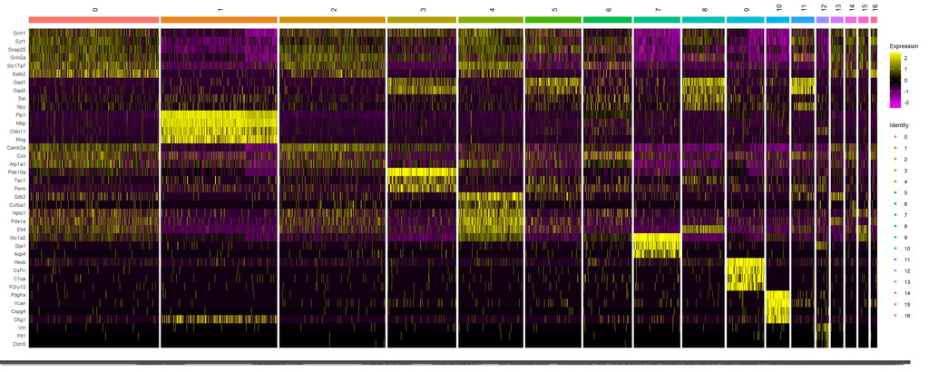

```r
Idents(objects)<- objects$seurat_clusters

DoHeatmap(objects,
          features = c(
            "Grin1", "Syt1", "Snap25", "Grin2a", "Slc17a7", "Satb2",
            "Gad1", "Gad2", "Sst", "Npy", "Plp1", "Mbp", "Cldn11", "Mog",
            "Camk2a", "Cck", "Atp1a1", "Pde10a", "Tac1", "Penk", "Sdk2",
            "Col5a1", "Nptx1", "Pde1a", "Etl4", "Slc1a2", "Gja1", "Aqp4",
            "Hexb", "Csf1r", "C1qa", "P2ry12", "Pdgfra", "Vcan", "Cspg4",
            "Olig1", "Vtn", "Flt1", "Cldn5"
          ),
          size = 3.5, angle = 90) +  base_theme +theme(legend.position = "right")
```

## 2.3 Functional enrichment analysis of upregulated genes

```r
dbs<- listEnrichrDbs()
#head(dbs)
#grep("GO_", dbs$libraryName, value = TRUE)

DoEnrichment <-function(genes) {
  dbs <- c("GO_Molecular_Function_2023", "GO_Cellular_Component_2023", "GO_Biological_Processes_2023")
  enriched<- enrichR::enrichr(genes, dbs)
  return(enriched)
}


enrichment.pos <- DoEnrichment(genes = de.pos)
```

```
## Uploading data to Enrichr... Done.
##   Querying GO_Molecular_Function_2023... Done.
##   Querying GO_Cellular_Component_2023... Done.
##   Querying GO_Biological_Processes_2023... Done.
## Parsing results... Done.
```

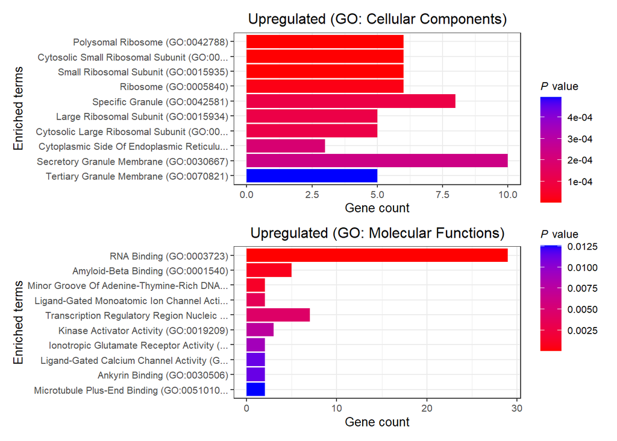

```r
p2 <- plotEnrich(enrichment.pos$GO_Cellular_Component_2023, showTerms = 10) +
  theme_bw(base_size = 10) +
  ggtitle("Upregulated (GO: Cellular Components)") +base_theme
p3 <- plotEnrich(enrichment.pos$GO_Molecular_Function_2023, showTerms = 10) +
  theme_bw(base_size = 10) +
  ggtitle("Upregulated (GO: Molecular Functions)") +base_theme

( p2 / p3) + plot_layout(guides = "collect")
```

## 2.4 Functional enrichment analysis of downregulated genes

```r
enrichment.neg <- DoEnrichment(genes = de.neg)
```

```
## Uploading data to Enrichr... Done.
##   Querying GO_Molecular_Function_2023... Done.
##   Querying GO_Cellular_Component_2023... Done.
##   Querying GO_Biological_Processes_2023... Done.
## Parsing results... Done.
```

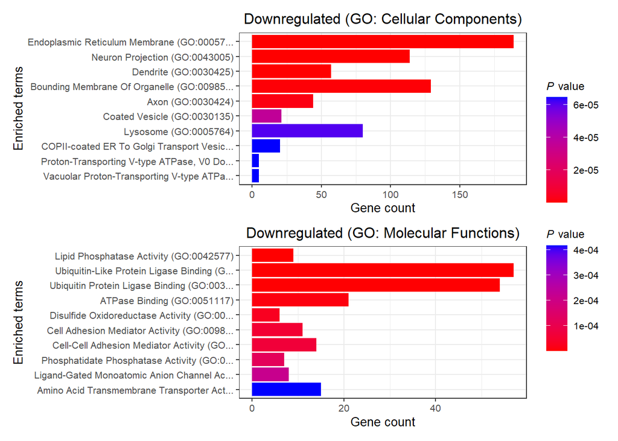

```r
p2 <- plotEnrich(enrichment.neg$GO_Cellular_Component_2023, showTerms = 10) +
  theme_bw(base_size = 10) +
  ggtitle("Downregulated (GO: Cellular Components)")+base_theme
p3 <- plotEnrich(enrichment.neg$GO_Molecular_Function_2023, showTerms = 10) +
  theme_bw(base_size = 10) +
  ggtitle("Downregulated (GO: Molecular Functions)") +base_theme
( p2 / p3) + plot_layout(guides = "collect")
```

A large number of downregulated genes are linked to ubiquitin or ubiquitin like proteins potentially regulating protein degradation pathways. Other downregulated molecular functions include lipid phosphatase activity, disulfide oxidoreductase activity, ATPase binding, and cell-cell adhesion mediator activity, possibly indicating impaired lipid signaling, reduced cellular redox balance, disrupted energy metabolism, and weakened intercellular communication. The downregulated cellular components include ER membrane, bounding membrane of organelle, lysosome, coated Vesicle and COPII-coated ER to Golgi transport vesicle indicating suppression of intracellular transport and organelle membrane integrity. The cellular components crucial to neuronal activity like neuron projection, axon, and dendrite are also enriched suggesting reduced neuronal activity and neurodegeneration.

# 3 Identifying Microglial sub-population

## 3.1 Proportions of clusters in 5XFAD and WT dataset

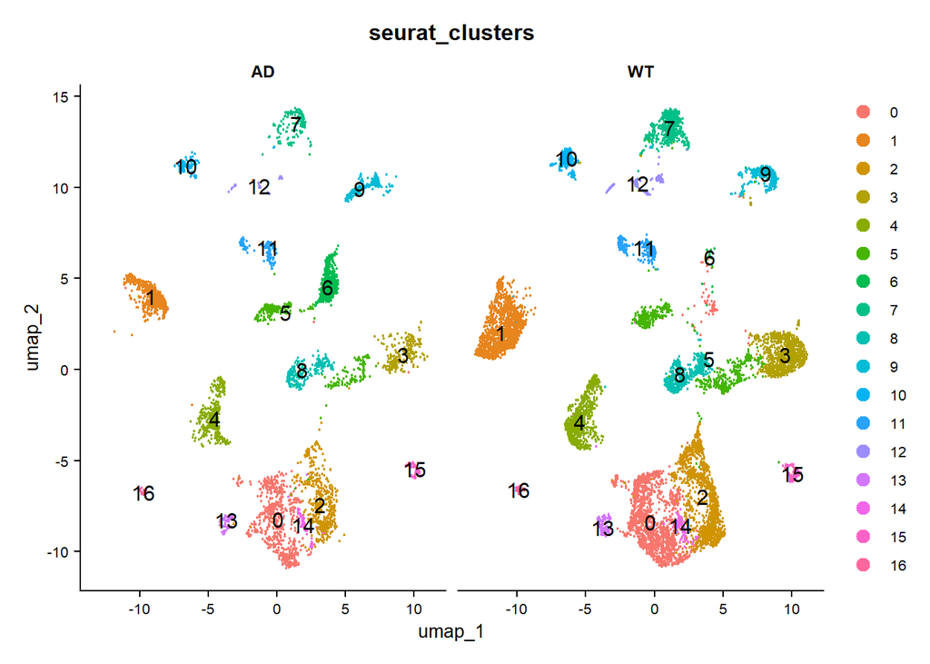

```r
DimPlot(objects, split.by = "sample_name", group.by = "seurat_clusters", label = TRUE) +base_theme
```

The clusters not only differ in number of cells but also in their arrangement in 5XFAD and WT.

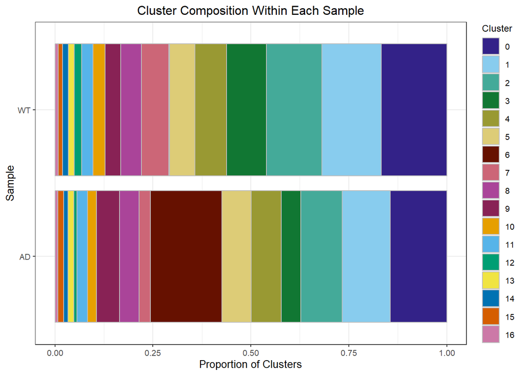

```r
Idents(objects)<-objects$seurat_clusters
sample_cluster_counts <- as.data.frame(table(
  Sample = objects$sample_name,
  Cluster = Idents(objects)
))

sample_props <- sample_cluster_counts %>%
  group_by(Sample) %>%
  mutate(Proportion = Freq / sum(Freq))

custom_colors <- c(
  "0" = "#332288",  "1" = "#88CCEE",  "2" = "#44AA99","3" = "#117733","4" = "#999933","5" = "#DDCC77",  "6" = "#661100",  "7" = "#CC6677",  "8" = "#AA4499",  "9" = "#882255","10" = "#E69F00", "11" = "#56B4E9","12" = "#009E73",  "13" = "#F0E442", "14" = "#0072B2", "15" = "#D55E00", "16" = "#CC79A7")


ggplot(sample_props, aes(x = Sample, y = Proportion, fill = Cluster)) +
  geom_bar(stat = "identity", position = "fill", color = "grey") +
  coord_flip() +
  ylab("Proportion of Clusters") +
  xlab("Sample") +
  theme_bw(base_size = 10) +
  scale_fill_manual(values = custom_colors) +
  ggtitle("Cluster Composition Within Each Sample") +base_theme
```

The proportion of clusters in 5XFAD and WT each dataset also varies. Some clusters have similar proportion in both datasets, like Cluster 8 and 16 whereas it changes drastically for others clusters like Cluster 6.

## 3.2 Expression of microglial marker genes across clusters

To identify the cells in microglial subpopulation, the expression of microglia-specific markers like C1qa, P2ry12, Cx3cr1, Fcrls, Csf1r and Tyrobp are obtained. Of these, C1qa and Csf1r are homeostatic markers of microglia.

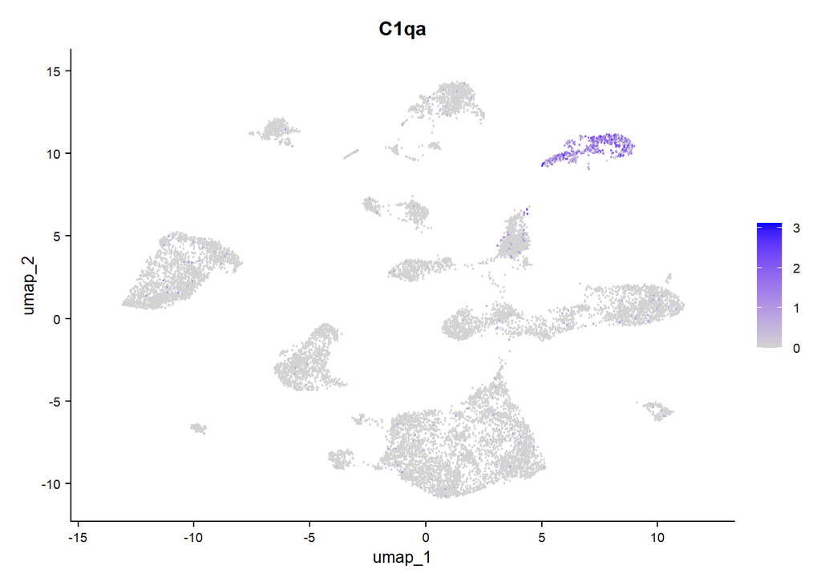

```r
FeaturePlot(objects, features = c("C1qa")) +base_theme
```

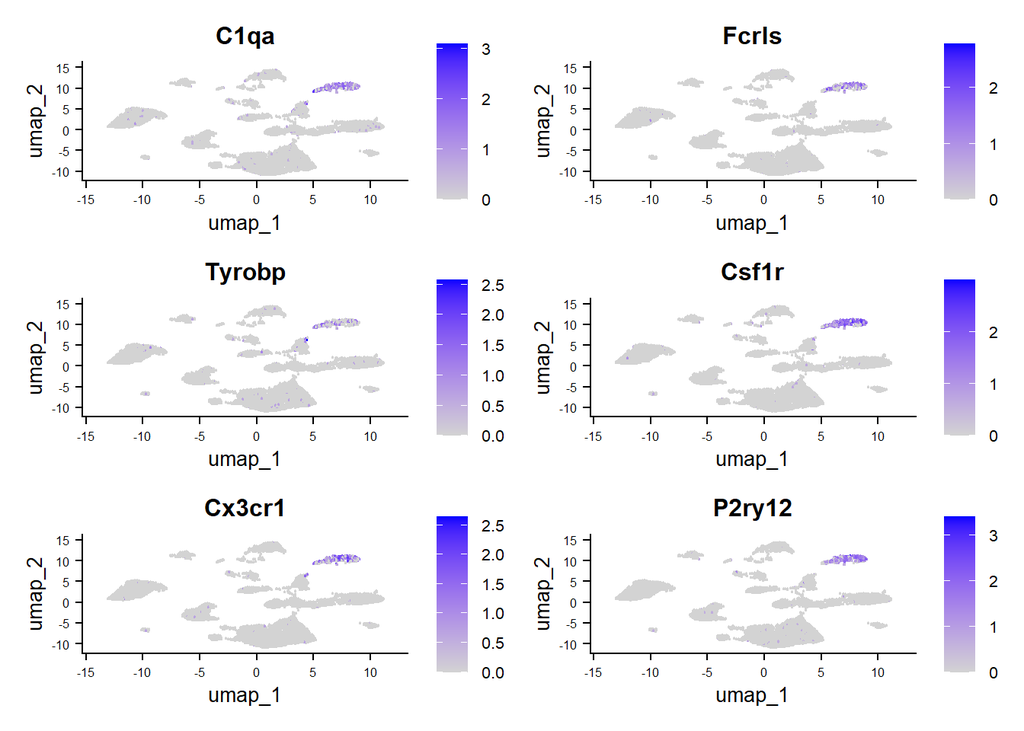

```r
plots <- FeaturePlot(
  objects,
  features = c("C1qa", "Fcrls", "Tyrobp", "Csf1r", "Cx3cr1", "P2ry12"),
  combine = FALSE
)
plots <- lapply(plots, function(p) {
  p + base_theme +
    theme(
      axis.text.y = element_text(size = 6),
      axis.text.x = element_text(size = 6),
      axis.title = element_text(size = 8)
    )
})

wrap_plots(plots, ncol = 2)
```

The co-expression of microglial marker genes in same clusters suggests it to be a microglial cell population.

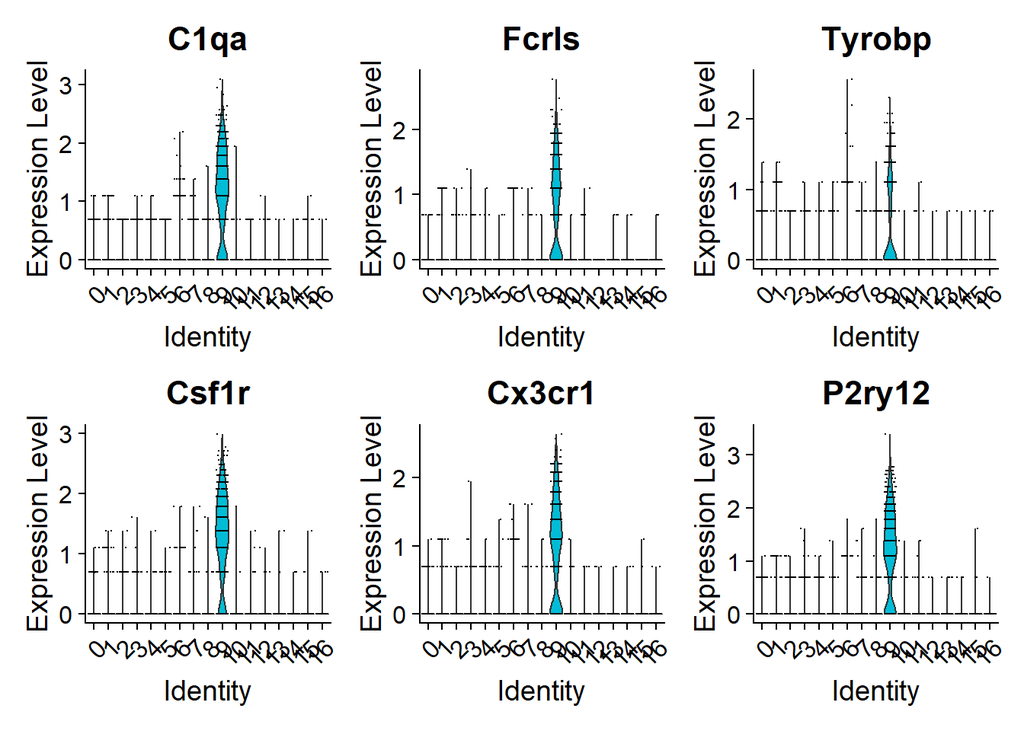

```r
VlnPlot(objects, features = c("C1qa", "Fcrls", "Tyrobp", "Csf1r", "Cx3cr1", "P2ry12") )
```

The violin plots above show the expression patterns of the microglial marker genes across all identified clusters. All six markers show high and specific gene expression in Cluster 9, while having low expression in other clusters. So, this suggests that Cluster 9 represents a microglial subpopulation.

```r
microglia <- subset(objects, idents = 9)
print(subset(sample_props, Cluster == "9"))
```

```
## # A tibble: 2 × 4
## # Groups:   Sample [2]
##   Sample Cluster  Freq Proportion
##   <fct>  <fct>   <int>      <dbl>
## 1 AD     9         268     0.0588
## 2 WT     9         384     0.0398
```

## 3.3 Identifying differentially expressed genes in microglial cluster

```r
microglia <- PrepSCTFindMarkers(microglia)
head(microglia)
```

|  | orig.ident | nCount_RNA | nFeature_RNA | percent.mt | sample_name | nCount_SCT | nFeature_SCT | SCT_snn_res.0.3 | seurat_clusters |
| --- | --- | --- | --- | --- | --- | --- | --- | --- | --- |
| WT_AAACCTGTCCTCGCAT-1 | WT_1 | 1005 | 825 | 0.59701493 | WT | 2086 | 956 | 9 | 9 |
| WT_AAAGCAACAGCTTCGG-1 | WT_1 | 797 | 672 | 0.25094103 | WT | 1989 | 878 | 9 | 9 |
| WT_AAAGTAGAGCCCTAAT-1 | WT_1 | 799 | 678 | 0.00000000 | WT | 1945 | 896 | 9 | 9 |
| WT_AAAGTAGCAATGGATA-1 | WT_1 | 4258 | 2675 | 0.04697041 | WT | 3981 | 2603 | 9 | 9 |
| WT_AAAGTAGTCGGTGTTA-1 | WT_1 | 1174 | 980 | 0.42589438 | WT | 2282 | 1063 | 9 | 9 |
| WT_AAATGCCAGGGAAACA-1 | WT_1 | 1041 | 843 | 0.00000000 | WT | 2136 | 962 | 9 | 9 |
| WT_AACCATGAGAGGTTAT-1 | WT_1 | 1843 | 1380 | 0.48833424 | WT | 2522 | 1365 | 9 | 9 |
| WT_AACCATGGTATCGCAT-1 | WT_1 | 1001 | 808 | 0.19980020 | WT | 2089 | 947 | 9 | 9 |
| WT_AACCGCGCATGCTAGT-1 | WT_1 | 1135 | 923 | 0.17621145 | WT | 2244 | 1017 | 9 | 9 |
| WT_AACGTTGAGAGATGAG-1 | WT_1 | 982 | 799 | 0.20366599 | WT | 2104 | 939 | 9 | 9 |

[output not shown]

1-10 of 10 rows | 1-6 of 10 columns

```r
Idents(microglia)<- microglia$sample_name
unique(Idents(microglia))
```

```
## [1] WT AD
## Levels: WT AD
```

```r
microglia.markers <- FindMarkers(microglia, ident.1 = "AD", ident.2 = "WT", verbose = TRUE, recorrect_umi = FALSE)

microglia.markers$gene <- rownames(microglia.markers)
microglia.markers$log10_pval <- -log10(microglia.markers$p_val_adj)
microglia.markers$significant <- with(microglia.markers,
                                     ifelse(p_val_adj < 0.05 & abs(avg_log2FC) > 0.5, "Yes", "No")
)

write.csv(microglia.markers, file = "microglia_degs.csv", row.names = FALSE)
head(microglia.markers)
```

|  | p_val | avg_log2FC | pct.1 | pct.2 | p_val_adj | gene | log10_pval | significant |
| --- | --- | --- | --- | --- | --- | --- | --- | --- |
| Csf1 | 1.364593e-30 | 3.8534752 | 0.410 | 0.049 | 2.572122e-26 | Csf1 | 25.58971 | Yes |
| Apoe | 2.178645e-27 | 2.0307077 | 0.668 | 0.273 | 4.106529e-23 | Apoe | 22.38653 | Yes |
| Myo1e | 1.111153e-24 | 2.9075704 | 0.373 | 0.055 | 2.094412e-20 | Myo1e | 19.67894 | Yes |
| Cst7 | 1.429992e-24 | 7.7283267 | 0.246 | 0.000 | 2.695393e-20 | Cst7 | 19.56938 | Yes |
| Phactr1 | 3.126751e-23 | -0.9422175 | 0.373 | 0.859 | 5.893613e-19 | Phactr1 | 18.22962 | Yes |
| Lpl | 3.724076e-22 | 4.9518327 | 0.257 | 0.013 | 7.019511e-18 | Lpl | 17.15369 | Yes |

[output not shown]

6 rows

```r
de.microglia.pos = microglia.markers %>%
  filter(avg_log2FC>0) %>% filter(p_val_adj<0.05) %>% pull (gene)
length(de.microglia.pos)
```

```
## [1] 121
```

```r
de.microglia.neg = microglia.markers %>%
  filter(avg_log2FC<0) %>% filter(p_val_adj<0.05) %>% pull (gene)
length(de.microglia.neg)
```

```
## [1] 52
```

Through this analysis, 121 genes were found to be upregulated in microglial sub-population of 5XFAD cells as compared to WT mice cells while 52 of them were down-regulated.

```r
top_genes <- microglia.markers[microglia.markers$significant == "Yes", ]
top_genes <- top_genes[order(top_genes$avg_log2FC, decreasing = TRUE), ]

head(top_genes)
```

|  | p_val | avg_log2FC | pct.1 | pct.2 | p_val_adj | gene | log10_pval | significant |
| --- | --- | --- | --- | --- | --- | --- | --- | --- |
| Cst7 | 1.429992e-24 | 7.728327 | 0.246 | 0 | 2.695393e-20 | Cst7 | 19.569378 | Yes |
| Baiap2l2 | 1.544793e-21 | 7.246794 | 0.216 | 0 | 2.911780e-17 | Baiap2l2 | 16.535842 | Yes |
| Itgax | 1.584633e-13 | 6.401516 | 0.134 | 0 | 2.986875e-09 | Itgax | 8.524783 | Yes |
| Ccl3 | 8.047547e-13 | 6.376854 | 0.127 | 0 | 1.516882e-08 | Ccl3 | 7.819048 | Yes |
| Fgr | 1.223547e-07 | 5.563267 | 0.071 | 0 | 2.306264e-03 | Fgr | 2.637091 | Yes |
| Cd300lf | 5.580490e-08 | 5.473070 | 0.075 | 0 | 1.051867e-03 | Cd300lf | 2.978039 | Yes |

[output not shown]

6 rows

The genes upregulated in microglia include: -Cst7 (which inhibits papain and cathepsin L, and is speculated to play a role in immune regulation of haematopoietic system), -Ccl3 (which codes for monokine with inflammatory and cytokinetic properties ) and -Itgax (which codes for integrin alpha-X protein, which mediates cell-cell interaction durign infammatory response.) DAM genes, including Cst7, Csf1, Apoe, Trem2, Lilrb4a are all significantly upregulated in 5XFAD as compared to WT mice. In addition to this, homeostatic genes such as P2ry12, Selplg, and Tmem119 are downregulated in 5XFAD as compared to WT mice.

```r
top_up <- microglia.markers %>%
  filter(p_val_adj < 0.05) %>%
  filter(avg_log2FC >0.5) %>%
  top_n(n = 5, wt = avg_log2FC)


top_downregulated_genes <- microglia.markers %>%
  filter(avg_log2FC < -0.5, p_val_adj < 0.5) %>%
  arrange(avg_log2FC)%>%
  head(5)
```

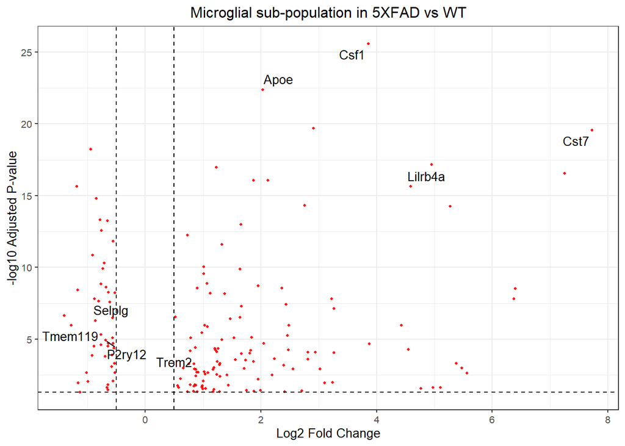

```r
label_genes <- c("P2ry12", "Selplg", "Tmem119", "Cst7", "Csf1", "Apoe", "Trem2", "Lilrb4a")
label_df <- top_genes %>% filter(gene %in% label_genes)

ggplot(top_genes, aes(x = avg_log2FC, y = log10_pval)) +
  geom_point(color = "red", alpha = 0.9, size = 0.8) +
  geom_vline(xintercept = c(-0.5, 0.5), linetype = "dashed") +
  geom_hline(yintercept = -log10(0.05), linetype = "dashed") +
  geom_text_repel(data = label_df, aes(label = gene), size = 3.5, max.overlaps = 50) +
  theme_bw(base_size = 10) +
  labs(
    title = "Microglial sub-population in 5XFAD vs WT",
    x = "Log2 Fold Change",
    y = "-log10 Adjusted P-value"
  ) +
  theme(legend.position = "none") +
  base_theme
```

## 3.4 Functional enrichment analysis of DEGs in microglial sub-population

```r
enrichment.microglia.pos <- DoEnrichment(genes = de.microglia.pos)
```

```
## Uploading data to Enrichr... Done.
##   Querying GO_Molecular_Function_2023... Done.
##   Querying GO_Cellular_Component_2023... Done.
##   Querying GO_Biological_Processes_2023... Done.
## Parsing results... Done.
```

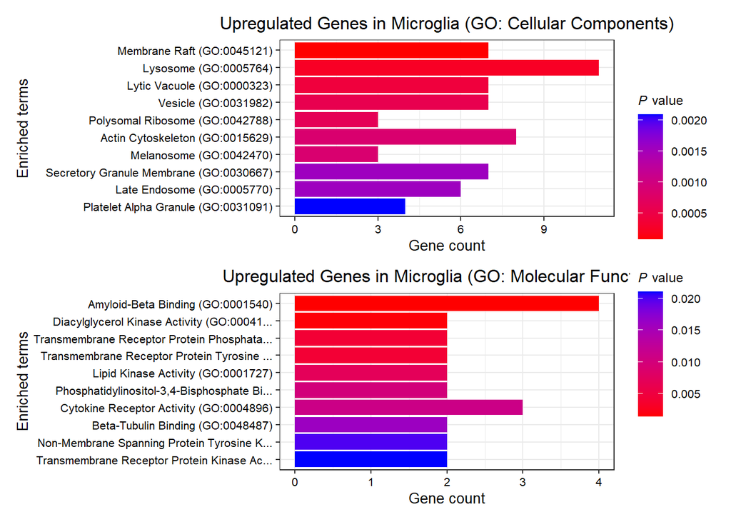

```r
p2 <- plotEnrich(enrichment.microglia.pos$GO_Cellular_Component_2023, showTerms = 10) +
  ggtitle("Upregulated Genes in Microglia (GO: Cellular Components)")+ base_theme
p3 <- plotEnrich(enrichment.microglia.pos$GO_Molecular_Function_2023, showTerms = 10) +
  ggtitle("Upregulated Genes in Microglia (GO: Molecular Functions)")+ base_theme


( p2 / p3) + plot_layout(guides = "collect")
```

```r
enrichment.microglia.neg <- DoEnrichment(genes = de.microglia.neg)
```

```
## Uploading data to Enrichr... Done.
##   Querying GO_Molecular_Function_2023... Done.
##   Querying GO_Cellular_Component_2023... Done.
##   Querying GO_Biological_Processes_2023... Done.
## Parsing results... Done.
```

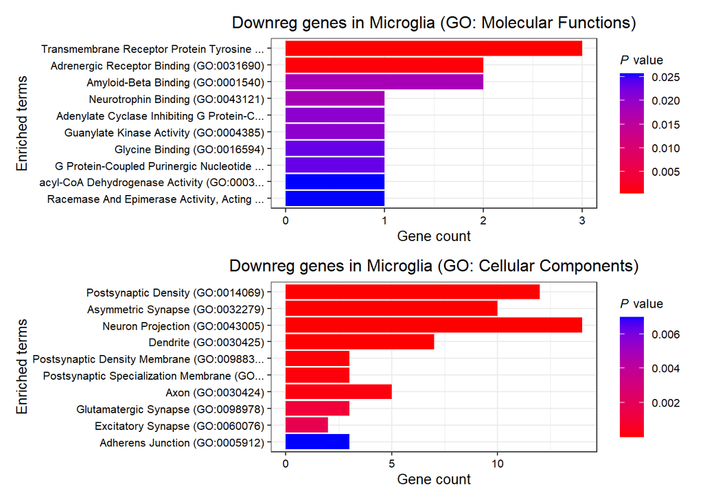

```r
p1<-plotEnrich(df = enrichment.microglia.neg$GO_Molecular_Function_2023, showTerms = 10) + ggtitle("Downreg genes in Microglia (GO: Molecular Functions)") +base_theme
p2<-plotEnrich(df = enrichment.microglia.neg$GO_Cellular_Component_2023, showTerms = 10) + ggtitle("Downreg genes in Microglia (GO: Cellular Components)") + base_theme
p1 / p2
```

# 4 Expression of gene “Cst7”

From differential expression analysis in 5XFAD vs WT, we know that “Cst7” gene is one of the most upregulated genes in diseased microglial cells. It codes for the protein cystatin F (CF) and has been shown in literature to be among the robustly upregulated genes in the Disease Associated Microglia (DAM) signature.

It is shown in [Michael JD et al. 2023](https://doi.org/10.7554/eLife.85279) that Cst7/CF played a role in microglial amyloid uptake and endolysosomal gene expression female mice and this led to a modest increase in Aβ plaque pathology in specific brain areas. This relationship between microglial phagocytosis and plaques is still an important question. This is counterintuitive, as microglial phagocytosis is typically thought to reduce plaques. However, some studies suggests that phagocytic microglia may contribute to plaque formation, rather than clearance.

## 4.1 Expression of “Cst7” in microglial cluster

```r
cst7_counts <- FetchData(objects, vars = "Cst7")
sum(cst7_counts$Cst7 > 0)
```

```
## [1] 108
```

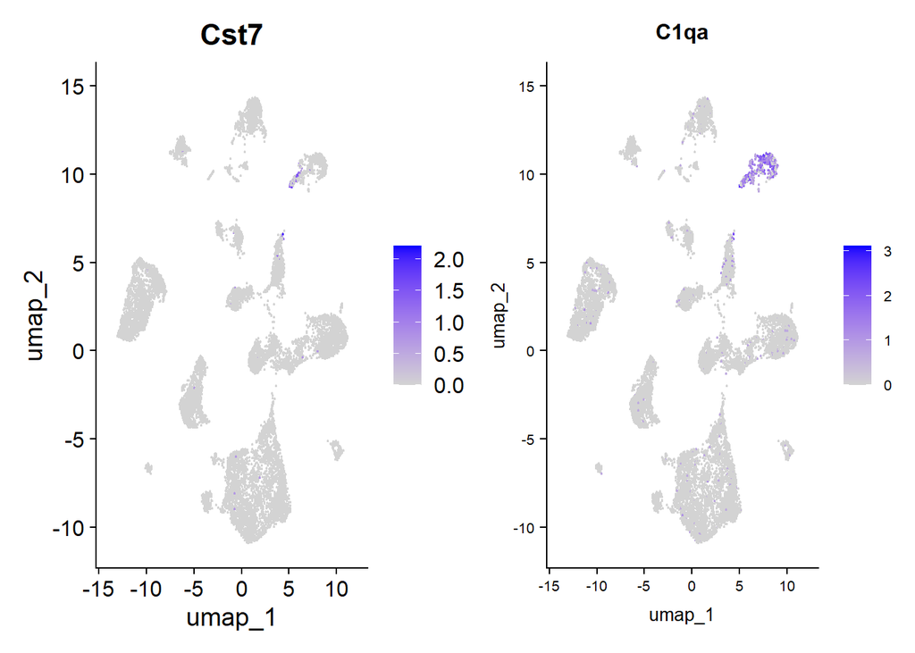

```r
FeaturePlot(objects, features = c("Cst7", "C1qa")) +base_theme
```

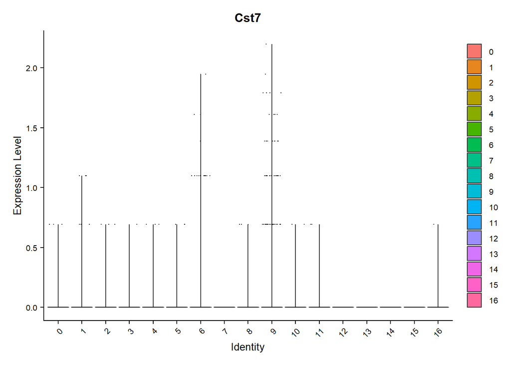

```r
VlnPlot(objects, features = c("Cst7")) +base_theme
```

Gene “Cst7” is a cluster-specific gene in this dataset where its overall expression is scanty with 108 counts across clusters. The gene is expressed in cluster 6 and cluster 9 (microglial subpopulation).

## 4.2 Expression of “Cst7” in microglial sub-clusters

Reclustering microglial subpopulation showed that there is 1 distinct sub-cluster which constitutes 5XFAD sample and is enriched in Cst7 gene.

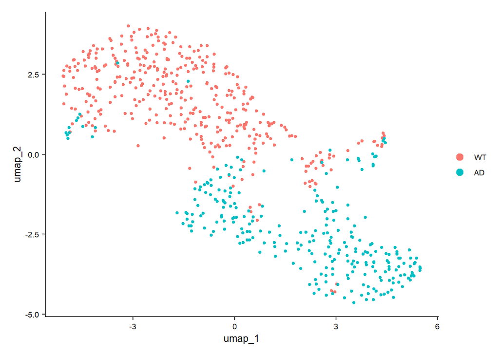

```r
microglia<- RunUMAP(microglia, reduction = "pca", dims = 1:30)
DimPlot(microglia) +base_theme
```

```r
microglia <- FindNeighbors(microglia, reduction = "pca", dims = 1:30)
microglia <-FindClusters(microglia, resolution = 0.3)
```

```
## Modularity Optimizer version 1.3.0 by Ludo Waltman and Nees Jan van Eck
##
## Number of nodes: 652
## Number of edges: 21765
##
## Running Louvain algorithm...
## Maximum modularity in 10 random starts: 0.8342
## Number of communities: 4
## Elapsed time: 0 seconds
```

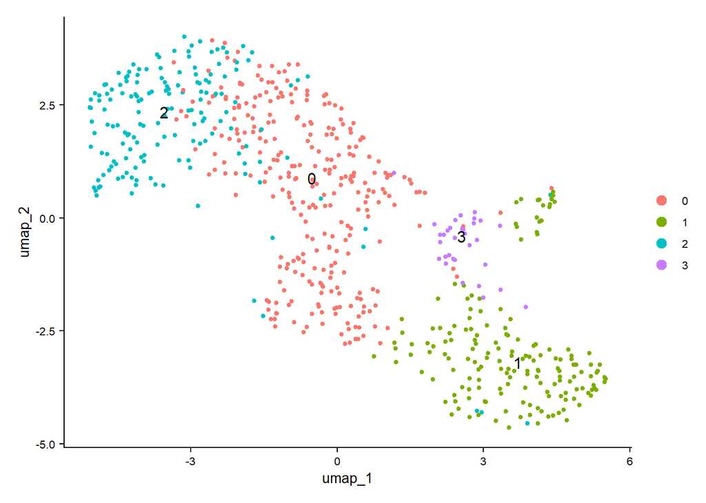

```r
DimPlot(microglia, label = TRUE) +base_theme
```

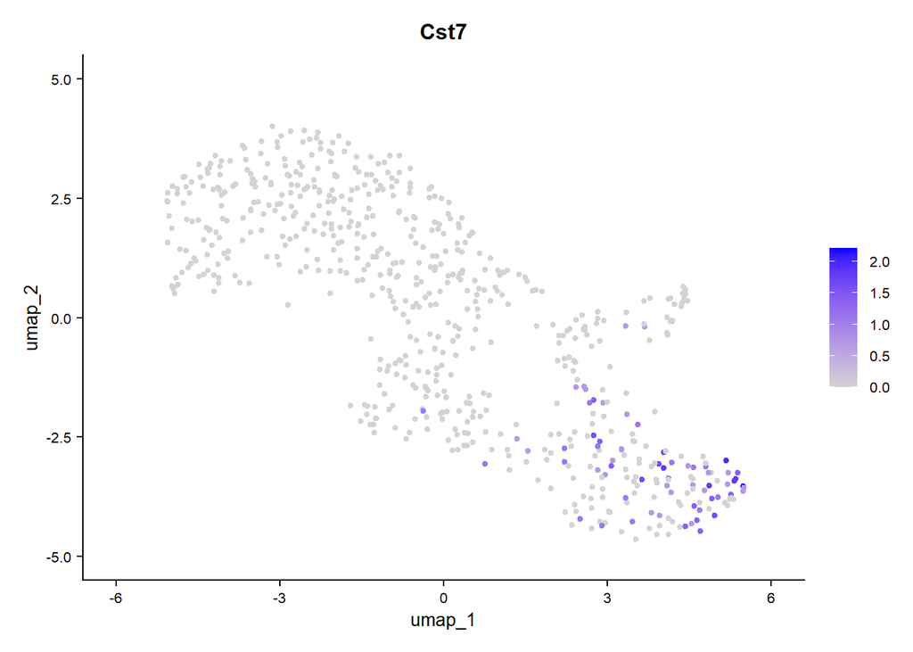

```r
FeaturePlot(microglia, features = c("Cst7")) +base_theme
```

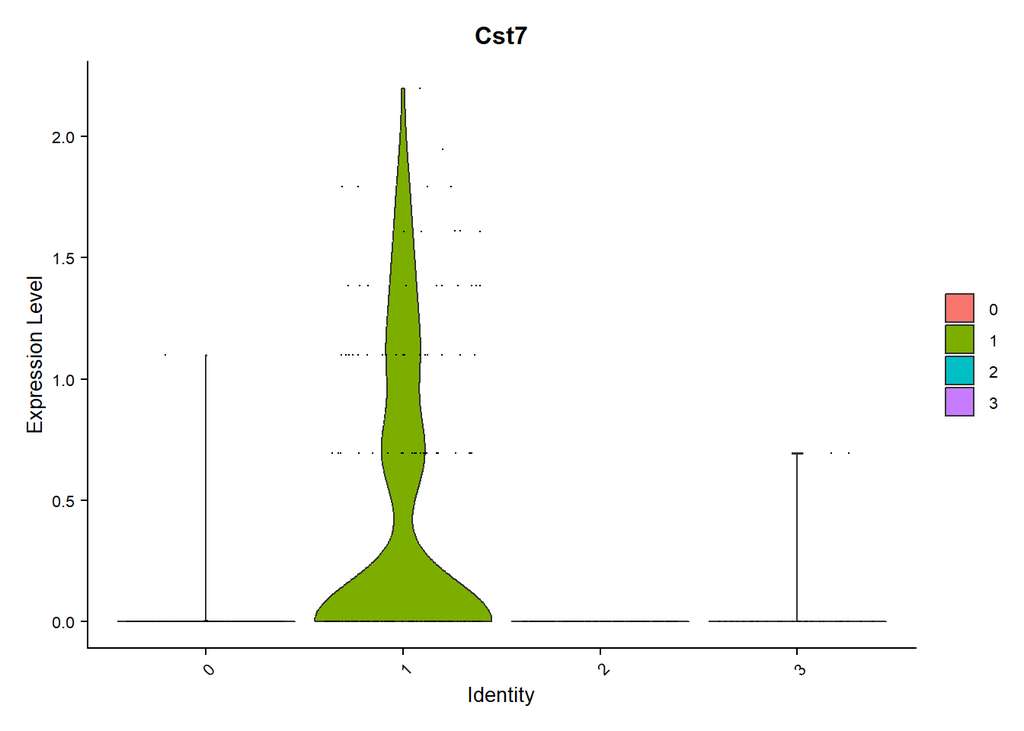

```r
VlnPlot(microglia, features = c("Cst7")) +base_theme
```

<br>Expression of Cst7 is enriched in sub-cluster 1, which is largely composed of cells from 5XFAD sample. The upregulation of Cst7/CF expression at both the RNA and protein level has been shown to be spatially localised to plaques (Chen et al., 2020). It is possible that, Cst7 expression is driven by amyloid plaques present in Alzheimer’s disease model “5XFAD” cells.